# Astropy: Handling FITS files

```python
%matplotlib inline
import numpy as np
import matplotlib.pyplot as plt
```

## Documentation

For more information about the features presented below, you can read the [astropy.io.fits](http://docs.astropy.org/en/stable/io/fits/index.html) docs.

## Data

The data used in this page is a model of the gamma-ray sky background used for the LAT instrument on the Fermi telescope, as well as the *Fermi*/LAT point source catalog.

## Reading FITS files and accessing data

Opening a FITS file is relatively straightforward. We can open the background model included in the tutorial files:

```python
from astropy.io import fits
```

```python
hdulist = fits.open('data/gll_iem_v02_P6_V11_DIFFUSE.fit')
```

The returned object, `hdulist`, behaves like a Python list, and each element maps to a Header-Data Unit (HDU) in the FITS file. You can view more information about the FITS file with:

```python
hdulist.info()
```

```
Filename: data/gll_iem_v02_P6_V11_DIFFUSE.fit
No.    Name         Type      Cards   Dimensions   Format
0    PRIMARY     PrimaryHDU      34   (720, 360, 30)   float32
1    ENERGIES    BinTableHDU     19   30R x 1C     [D]
```

As we can see, this file contains two HDUs. To access the primary HDU, which contains the main data, you can then do:

```python
hdu = hdulist[0]
```

The `hdu` object then has two important attributes: `data`, which behaves like a Numpy array, can be used to access the data, and `header`, which behaves like a dictionary, can be used to access the header information. First, we can take a look at the data:

```python
hdu.data.shape
```

```
(30, 360, 720)
```

This tells us that it is a 3-d cube. We can now take a peak at the header:

```python
hdu.header
```

```
SIMPLE  =                    T / Written by IDL:  Thu Jan 20 07:19:05 2011
BITPIX  =                  -32 /
NAXIS   =                    3 / number of data axes
NAXIS1  =                  720 / length of data axis 1
NAXIS2  =                  360 / length of data axis 2
NAXIS3  =                   30 / length of data axis 3
EXTEND  =                    T / FITS dataset may contain extensions
COMMENT   FITS (Flexible Image Transport System) format is defined in 'Astronomy
COMMENT   and Astrophysics', volume 376, page 359; bibcode: 2001A&A...376..359H
FLUX    =        8.42259635886 /
CRVAL1  =                   0. / Value of longitude in pixel CRPIX1
CDELT1  =                  0.5 / Step size in longitude
CRPIX1  =                360.5 / Pixel that has value CRVAL1
CTYPE1  = 'GLON-CAR'           / The type of parameter 1 (Galactic longitude in
CUNIT1  = 'deg     '           / The unit of parameter 1
CRVAL2  =                   0. / Value of latitude in pixel CRPIX2
CDELT2  =                  0.5 / Step size in latitude
CRPIX2  =                180.5 / Pixel that has value CRVAL2
CTYPE2  = 'GLAT-CAR'           / The type of parameter 2 (Galactic latitude in C
CUNIT2  = 'deg     '           / The unit of parameter 2
CRVAL3  =                  50. / Energy of pixel CRPIX3
CDELT3  =    0.113828620540137 / log10 of step size in energy (if it is logarith
CRPIX3  =                   1. / Pixel that has value CRVAL3
CTYPE3  = 'photon energy'      / Axis 3 is the spectra
CUNIT3  = 'MeV     '           / The unit of axis 3
CHECKSUM= '3fdO3caL3caL3caL'   / HDU checksum updated 2009-07-07T22:31:18
DATASUM = '2184619035'         / data unit checksum updated 2009-07-07T22:31:18
DATE    = '2009-07-07'         /
FILENAME= '$TEMPDIR/diffuse/gll_iem_v02.fit' /File name with version number
TELESCOP= 'GLAST   '           /
INSTRUME= 'LAT     '           /
ORIGIN  = 'LISOC   '           /LAT team product delivered from the LISOC
OBSERVER= 'MICHELSON'          /Instrument PI
HISTORY Scaled version of gll_iem_v02.fit for use with P6_V11_DIFFUSE
```

which shows that this is a Plate Carrée (`-CAR`) projection in Galactic Coordinates, and the third axis is photon energy. We can access individual header keywords using standard item notation:

```python
hdu.header['TELESCOP']
```

```
'GLAST'
```

```python
hdu.header['INSTRUME']
```

```
'LAT'
```

Provided that we started up `ipython` with the `--pylab` flag, we can plot one of the slices in photon energy:

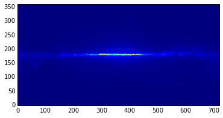

```python
plt.imshow(hdu.data[0,:,:], origin='lower')
```

Note that this is just a plot of an array, so the coordinates are just pixel coordinates at this stage. The data is stored with longitude increasing to the right (the opposite of the normal convention), but the Level 3 problem at the bottom of this page shows how to correctly flip the image.

Modifying data or header information in a FITS file object is easy. We can update existing header keywords:

```python
hdu.header['TELESCOP'] = "Fermi Gamma-ray Space Telescope"
```

or add new ones:

```python
hdu.header['MODIFIED'] = '21 Nov 2013'  # adds a new keyword
```

and we can also change the data, for example extracting only the first slice in photon energy:

```python
hdu.data = hdu.data[0,:,:]
```

Note that this does not change the original FITS file, simply the FITS file object in memory. Since the data is now 2-dimensional, we can remove the WCS keywords for the third dimension:

```python
hdu.header.remove('CRPIX3')
hdu.header.remove('CRVAL3')
hdu.header.remove('CDELT3')
hdu.header.remove('CUNIT3')
hdu.header.remove('CTYPE3')
```

You can write the FITS file object to a file with:

```python
hdu.writeto('lat_background_model_slice.fits', clobber=True)
```

if you want to simply write out this HDU to a file, or:

```python
hdulist.writeto('lat_background_model_slice_allhdus.fits', clobber=True)
```

if you want to write out all of the original HDUs, including the modified one, to a file.

## Creating a FITS file from scratch

If you want to create a FITS file from scratch, you need to start off by creating an HDU object:

```python
hdu = fits.PrimaryHDU()
```

and you can then populate the data and header attributes with whatever information you like:

```python
import numpy as np
```

```python
hdu.data = np.random.random((128,128))
```

Note that setting the data automatically populates the header with basic information:

```python
hdu.header
```

```
SIMPLE  =                    T / conforms to FITS standard
BITPIX  =                  -64 / array data type
NAXIS   =                    2 / number of array dimensions
NAXIS1  =                  128
NAXIS2  =                  128
EXTEND  =                    T
```

and you should never have to set header keywords such as `NAXIS`, `NAXIS1`, and so on manually. We can then set additional header keywords:

```python
hdu.header['telescop'] = 'Python Observatory'
```

and we can then write out the FITS file to disk:

```python
hdu.writeto('random_array.fits', clobber=True)
```

## Convenience functions

In cases where you just want to access the data or header in a specific HDU, you can use the following convenience functions:

```python
data = fits.getdata('data/gll_iem_v02_P6_V11_DIFFUSE.fit')
header = fits.getheader('data/gll_iem_v02_P6_V11_DIFFUSE.fit')
```

To get the data or header for an HDU other than the first, you can specify the extension name or index. The second HDU is called `energies`, so we can do:

```python
data = fits.getdata('data/gll_iem_v02_P6_V11_DIFFUSE.fit', extname='energies')
```

or:

```python
data = fits.getdata('data/gll_iem_v02_P6_V11_DIFFUSE.fit', ext=1)
```

and similarly for `getheader`.

## Accessing Tabular Data

Tabular data behaves very similarly to image data such as that shown above, but the data array is a structured Numpy array which requires column access via the item notation:

```python
from astropy.io import fits
hdulist = fits.open('data/gll_psc_v08.fit')
```

```python
hdulist[1].name
```

```
'LAT_Point_Source_Catalog'
```

```python
hdulist[1].data['RAJ2000']
```

```
array([  2.33711034e-01,   4.38849270e-01,   6.79812014e-01, ...,
         3.59759430e+02,   3.59859894e+02,   3.59906921e+02], dtype=float32)
```

```python
hdulist[1].data['DEJ2000']
```

```
array([ -7.81549788, -41.99647903,  62.33962631, ..., -30.62516785,
        67.86333466,  65.73053741], dtype=float32)
```

However, as we saw on the notes on the Table class, it is often easier to simply read in FITS tables using `Table.read`:

```python
from astropy.table import Table
t = Table.read('data/gll_psc_v08.fit')
```

[output not shown]

## Practical Exercises

### Level 1

Try and read in one of your own FITS files using `astropy.io.fits`, and see if you can also plot the array values in Matplotlib. Also, examine the header, and try and extract individual values. You can even try and modify the data/header and write the data back out - but take care not to write over the original file!

### Level 2

Read in the LAT Point Source Catalog (data/gll_psc_v08.fit) and make a scatter plot of the Galactic Coordinates of the sources (complete with axis labels). Bonus points if you can make the plot go between -180 and 180 instead of 0 and 360 degrees. Note that the Point Source Catalog contains the Galactic Coordinates, so no need to convert them.

### Level 3

Using Matplotlib, make an all-sky plot of the LAT Background Model in the Plate Carée projection showing the LAT Point Source Catalog overlaid with markers, and with the correct coordinates on the axes. You should do this using only `astropy.io.fits`, Numpy, and Matplotlib (no WCS or coordinate conversion library). Hint: the -CAR projection is such that the x pixel position is proportional to longitude, and the y pixel position to latitude. Bonus points for a pretty colormap.